# Practical Machine Learning Final Project Submission

Ed Loessi

May 20, 2018

## Practical Machine Learning Project Background

Using devices such as Jawbone Up, Nike FuelBand, and Fitbit it is now possible to collect a large amount of data about personal activity relatively inexpensively. These type of devices are part of the quantified self movement - a group of enthusiasts who take measurements about themselves regularly to improve their health, to find patterns in their behavior, or because they are tech geeks. One thing that people regularly do is quantify how much of a particular activity they do, but they rarely quantify how well they do it.

In this project, your goal will be to use data from accelerometers on the belt, forearm, arm, and dumbell of 6 participants. They were asked to perform barbell lifts correctly and incorrectly in 5 different ways. More information is available from the website here: http://groupware.les.inf.puc-rio.br/har (see the section on the Weight Lifting Exercise Dataset).

## Load the Required Training and Test Data

```r
TrainingData <- read.csv(url("https://d396qusza40orc.cloudfront.net/predmachlearn/pml-training.csv"),header=TRUE)
dim(TrainingData)
```

```
## [1] 19622   160
```

```r
TestingData <- read.csv(url("https://d396qusza40orc.cloudfront.net/predmachlearn/pml-testing.csv"),header=TRUE)
dim(TestingData)
```

```
## [1]  20 160
```

```r
head(TrainingData)
```

```
##   X user_name raw_timestamp_part_1 raw_timestamp_part_2   cvtd_timestamp
## 1 1  carlitos           1323084231               788290 05/12/2011 11:23
## 2 2  carlitos           1323084231               808298 05/12/2011 11:23
## 3 3  carlitos           1323084231               820366 05/12/2011 11:23
## 4 4  carlitos           1323084232               120339 05/12/2011 11:23
## 5 5  carlitos           1323084232               196328 05/12/2011 11:23
## 6 6  carlitos           1323084232               304277 05/12/2011 11:23
##   new_window num_window roll_belt pitch_belt yaw_belt total_accel_belt
## 1         no         11      1.41       8.07    -94.4                3
## 2         no         11      1.41       8.07    -94.4                3
## 3         no         11      1.42       8.07    -94.4                3
## 4         no         12      1.48       8.05    -94.4                3
## 5         no         12      1.48       8.07    -94.4                3
## 6         no         12      1.45       8.06    -94.4                3
##   kurtosis_roll_belt kurtosis_picth_belt kurtosis_yaw_belt
```

[output cut: 265 more lines]

```r
tail(TrainingData)
```

```
##           X user_name raw_timestamp_part_1 raw_timestamp_part_2
## 19617 19617    adelmo           1322832937               588324
## 19618 19618    adelmo           1322832937               588376
## 19619 19619    adelmo           1322832937               596287
## 19620 19620    adelmo           1322832937               636283
## 19621 19621    adelmo           1322832937               964299
## 19622 19622    adelmo           1322832937               972293
##         cvtd_timestamp new_window num_window roll_belt pitch_belt yaw_belt
## 19617 02/12/2011 13:35         no        864       148      -34.7      129
## 19618 02/12/2011 13:35         no        864       147      -34.8      129
## 19619 02/12/2011 13:35         no        864       145      -35.3      130
## 19620 02/12/2011 13:35         no        864       145      -35.5      130
## 19621 02/12/2011 13:35         no        864       143      -35.9      131
## 19622 02/12/2011 13:35        yes        864       143      -36.0      132
##       total_accel_belt kurtosis_roll_belt kurtosis_picth_belt
```

[output cut: 286 more lines]

## Cleaning the Training and Testing Data

The training data set contains 19622 observations on 160 columns. A close observation of the head and tail data summary shows that many of the columns contain NA results, which means they won’t provide any useful results for our purposes. Additionally, the first seven columns provide information about the test subjects, which will also not be useful for our purposes, so we will also omit this data. The next two steps will remove the NA data on both the train and test data setsw.

### Clean NA values on the training dataset

```r
indColToRemove <- which(colSums(is.na(TrainingData) |TrainingData=="")>0.9*dim(TrainingData)[1])
TrainingDataClean <- TrainingData[,-indColToRemove]
TrainingDataClean <- TrainingDataClean[,-c(1:7)]
dim(TrainingDataClean)
```

```
## [1] 19622    53
```

### Clean NA values on the test set

```r
indColToRemove <- which(colSums(is.na(TestingData) |TestingData=="")>0.9*dim(TestingData)[1])
TestingDataClean <- TestingData[,-indColToRemove]
TestingDataClean <- TestingDataClean[,-1]
dim(TestingDataClean)
```

```
## [1] 20 59
```

## Partition the cleaned data into training and test sets

### Partition the traning data set

```r
set.seed(12345)
inTrain1 <- createDataPartition(TrainingDataClean$classe, p=0.75, list=FALSE)
Training1 <- TrainingDataClean[inTrain1,]
Testing1 <- TrainingDataClean[-inTrain1,]
dim(Training1)
```

```
## [1] 14718    53
```

```r
dim(Testing1)
```

```
## [1] 4904   53
```

Now that we have the data partitioned, we can develop several models and then select the one that performs best. In this project I am trying a random forest, classification tree, and a gradient boosting method. One important aspect of this process is the use of cross validation to reduce overfitting and improve the performance of the models. In this project I have selected 5 folds for the cross validation. The number of folds can vary but an increase in folds does not always add value and can often times increase the run times beyond the value of any increase in accuracy.

## Training using a classification tree approach

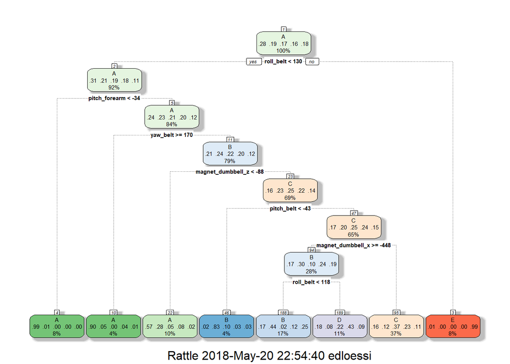

```r
trControl <- trainControl(method="cv", number=5)
model_CT <- train(classe~., data=Training1, method="rpart", trControl=trControl)
fancyRpartPlot(model_CT$finalModel)
```

## Predict - Confusion Matrix - Accuracy for Classification Tree

```r
trainpred <- predict(model_CT,newdata=Testing1)
confMatCT <- confusionMatrix(Testing1$classe,trainpred)
confMatCT$table
```

```
##           Reference
## Prediction   A   B   C   D   E
##          A 870 159 273  88   5
##          B 162 530 214  43   0
##          C  29  36 674 116   0
##          D  46 136 429 193   0
##          E  16 221 224  51 389
```

```r
confMatCT$overall[1]
```

```
##  Accuracy
## 0.5415987
```

## Train with random forests

```r
model_RF <- train(classe~., data=Training1, method="rf", trControl=trControl, verbose=FALSE)
print(model_RF)
```

```
## Random Forest
##
## 14718 samples
##    52 predictor
##     5 classes: 'A', 'B', 'C', 'D', 'E'
##
## No pre-processing
## Resampling: Cross-Validated (5 fold)
## Summary of sample sizes: 11776, 11775, 11773, 11774, 11774
## Resampling results across tuning parameters:
##
##   mtry  Accuracy   Kappa
##    2    0.9918466  0.9896855
##   27    0.9923226  0.9902884
##   52    0.9906918  0.9882252
##
## Accuracy was used to select the optimal model using the largest value.
## The final value used for the model was mtry = 27.
```

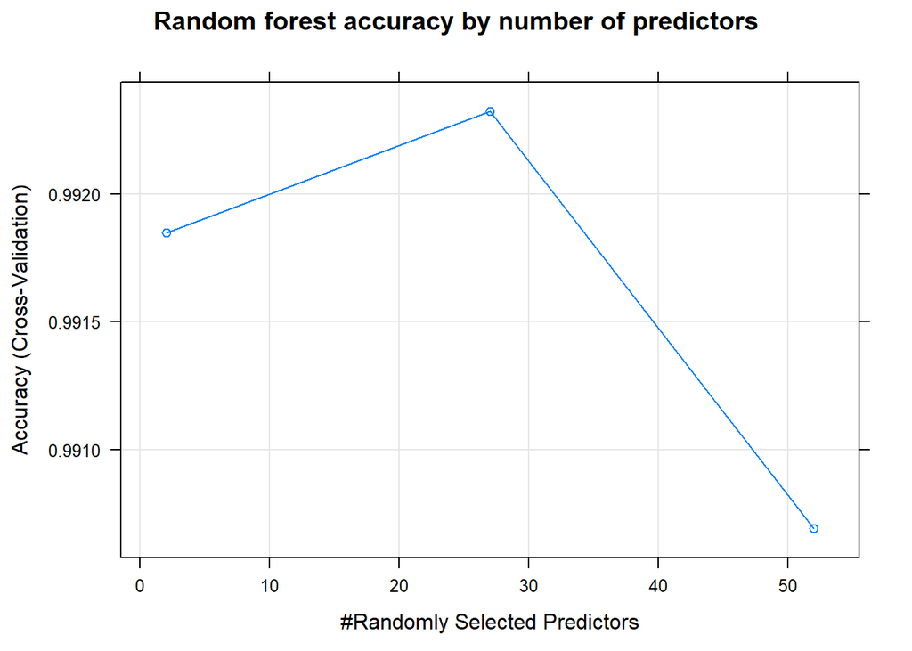

```r
plot(model_RF,main="Random forest accuracy by number of predictors")
```

## Predict - Confusion Matrix - Accuracy for Random Forest

```r
trainpred <- predict(model_RF,newdata=Testing1)
confMatRF <- confusionMatrix(Testing1$classe,trainpred)
confMatRF$table
```

```
##           Reference
## Prediction    A    B    C    D    E
##          A 1394    1    0    0    0
##          B    6  939    4    0    0
##          C    0    2  849    4    0
##          D    0    0   10  794    0
##          E    0    0    2    5  894
```

```r
confMatRF$overall[1]
```

```
##  Accuracy
## 0.9930669
```

## Additional Details for Random Forest and Plotting

```r
names(model_RF$finalModel)
```

```
##  [1] "call"            "type"            "predicted"
##  [4] "err.rate"        "confusion"       "votes"
##  [7] "oob.times"       "classes"         "importance"
## [10] "importanceSD"    "localImportance" "proximity"
## [13] "ntree"           "mtry"            "forest"
## [16] "y"               "test"            "inbag"
## [19] "xNames"          "problemType"     "tuneValue"
## [22] "obsLevels"       "param"
```

```r
model_RF$finalModel$classes
```

```
## [1] "A" "B" "C" "D" "E"
```

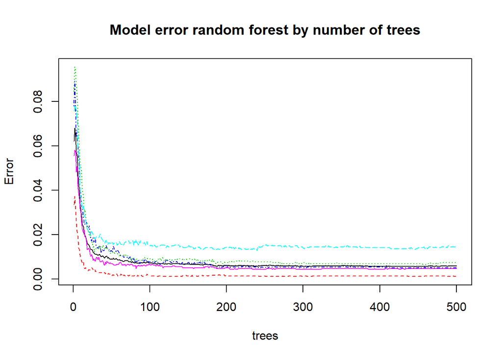

```r
plot(model_RF$finalModel,main="Model error random forest by number of trees")
```

## Variable Importance Random Forest

```r
MostImpVars <- varImp(model_RF)
MostImpVars
```

```
## rf variable importance
##
##   only 20 most important variables shown (out of 52)
##
##                      Overall
## roll_belt             100.00
## pitch_forearm          57.90
## yaw_belt               56.86
## magnet_dumbbell_z      44.51
## pitch_belt             44.02
## magnet_dumbbell_y      40.55
## roll_forearm           39.56
## accel_dumbbell_y       21.11
## magnet_dumbbell_x      17.90
## roll_dumbbell          17.68
## accel_forearm_x        17.27
## magnet_belt_z          14.44
## accel_dumbbell_z       14.16
## magnet_forearm_z       14.08
## total_accel_dumbbell   13.45
## magnet_belt_y          12.82
## accel_belt_z           12.02
## yaw_arm                11.39
## gyros_belt_z           10.48
## magnet_belt_x          10.18
```

## Train with gradient boosting method

```r
model_GBM <- train(classe~., data=Training1, method="gbm", trControl=trControl, verbose=FALSE)
print(model_GBM)
```

```
## Stochastic Gradient Boosting
##
## 14718 samples
##    52 predictor
##     5 classes: 'A', 'B', 'C', 'D', 'E'
##
## No pre-processing
## Resampling: Cross-Validated (5 fold)
## Summary of sample sizes: 11775, 11775, 11774, 11773, 11775
## Resampling results across tuning parameters:
##
##   interaction.depth  n.trees  Accuracy   Kappa
##   1                   50      0.7547203  0.6891712
##   1                  100      0.8194732  0.7714678
##   1                  150      0.8541930  0.8154916
##   2                   50      0.8585420  0.8207615
##   2                  100      0.9064419  0.8816012
##   2                  150      0.9317853  0.9136787
##   3                   50      0.8959101  0.8682235
##   3                  100      0.9406855  0.9249385
##   3                  150      0.9605249  0.9500546
##
## Tuning parameter 'shrinkage' was held constant at a value of 0.1
##
## Tuning parameter 'n.minobsinnode' was held constant at a value of 10
## Accuracy was used to select the optimal model using the largest value.
## The final values used for the model were n.trees = 150,
##  interaction.depth = 3, shrinkage = 0.1 and n.minobsinnode = 10.
```

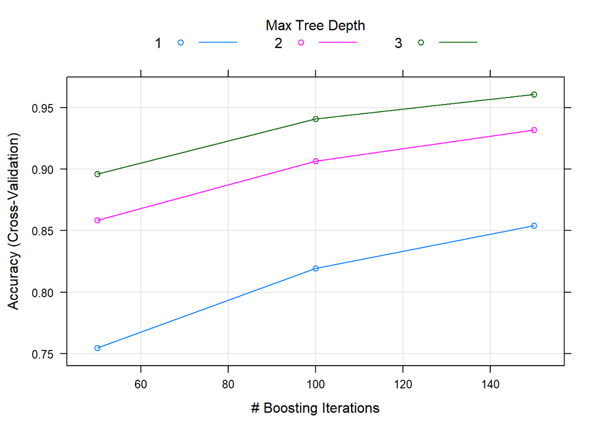

```r
plot(model_GBM)
```

## Predict - Confusion Matrix - Accuracy for Gradient Boost Method

```r
trainpred <- predict(model_GBM,newdata=Testing1)
confMatGBM <- confusionMatrix(Testing1$classe,trainpred)
confMatGBM$table
```

```
##           Reference
## Prediction    A    B    C    D    E
##          A 1378   14    3    0    0
##          B   39  874   34    1    1
##          C    0   20  824   10    1
##          D    0    1   21  776    6
##          E    3    7    8   16  867
```

```r
confMatGBM$overall[1]
```

```
##  Accuracy
## 0.9622757
```

### The final analysis across the three models

Based on the accuracy scores the random forest model with a score of 99.3+% is the clear winner in terms of model performance. Below are the results of the random forest model used on the test data provided.

```r
AccurateTestPred <- predict(model_RF,newdata=TestingDataClean)
AccurateTestPred
```

```
##  [1] B A B A A E D B A A B C B A E E A B B B
## Levels: A B C D E
```